# Lung-Cancer Analysis

Mukund Singh Kathait

```r
setwd("C:/Users/mukun/Downloads")
d <- read.table("LungCancer.txt", skip=15)
colnames(d) <- c("treatment", "cell_type", "survival",  "status",   "karnofsky_score",
                "months_from_diagnosis", "age", "prev_chemo")
View(d)
str(d)
```

```
## 'data.frame':    137 obs. of  8 variables:
##  $ treatment            : int  1 1 1 1 1 1 1 1 1 1 ...
##  $ cell_type            : int  1 1 1 1 1 1 1 1 1 1 ...
##  $ survival             : int  72 411 228 126 118 10 82 110 314 100 ...
##  $ status               : int  1 1 1 1 1 1 1 1 1 0 ...
##  $ karnofsky_score      : int  60 70 60 60 70 20 40 80 50 70 ...
##  $ months_from_diagnosis: int  7 5 3 9 11 5 10 29 18 6 ...
##  $ age                  : int  69 64 38 63 65 49 69 68 43 70 ...
##  $ prev_chemo           : int  0 10 0 10 10 0 10 0 0 0 ...
```

```r
col <- c("treatment", "cell_type", "prev_chemo")
d[col] <- lapply(d[col], factor)
str(d)
```

```
## 'data.frame':    137 obs. of  8 variables:
##  $ treatment            : Factor w/ 2 levels "1","2": 1 1 1 1 1 1 1 1 1 1 ...
##  $ cell_type            : Factor w/ 4 levels "1","2","3","4": 1 1 1 1 1 1 1 1 1 1 ...
##  $ survival             : int  72 411 228 126 118 10 82 110 314 100 ...
##  $ status               : int  1 1 1 1 1 1 1 1 1 0 ...
##  $ karnofsky_score      : int  60 70 60 60 70 20 40 80 50 70 ...
##  $ months_from_diagnosis: int  7 5 3 9 11 5 10 29 18 6 ...
##  $ age                  : int  69 64 38 63 65 49 69 68 43 70 ...
##  $ prev_chemo           : Factor w/ 2 levels "0","10": 1 2 1 2 2 1 2 1 1 1 ...
```

```r
d$treatment <- relevel(d$treatment, ref="1")
levels(d$prev_chemo) = c(0,1)
d$prev_chemo <- relevel(d$prev_chemo, ref="0")
```

Descriptive analysis

```r
summary(d$survival)
```

```
##    Min. 1st Qu.  Median    Mean 3rd Qu.    Max.
##     1.0    25.0    80.0   121.6   144.0   999.0
```

```r
table(d$treatment)
```

```
##
##  1  2
## 69 68
```

```r
table(d$status)
```

```
##
##   0   1
##   9 128
```

```r
table(d$cell_type)
```

```
##
##  1  2  3  4
## 35 48 27 27
```

```r
table(d$prev_chemo)
```

```
##
##  0  1
## 97 40
```

Obs: Almost equal number of standard treatment and test treatment, i.e., sample is balanced. 128 out of 137 patients died during the study and 9 patient records are censored. Survival variable: Event : Patient dies => status == 1 Time : survival Kaplan-Meier non-parametric analysis

```r
# install.packages("survival")
library(survival)
km <- survfit(Surv(survival, status) ~ treatment, data=d)
summary(km)
```

```
## Call: survfit(formula = Surv(survival, status) ~ treatment, data = d)
##
##                 treatment=1
##  time n.risk n.event survival std.err lower 95% CI upper 95% CI
##     3     69       1   0.9855  0.0144      0.95771        1.000
##     4     68       1   0.9710  0.0202      0.93223        1.000
##     7     67       1   0.9565  0.0246      0.90959        1.000
##     8     66       2   0.9275  0.0312      0.86834        0.991
##    10     64       2   0.8986  0.0363      0.83006        0.973
##    11     62       1   0.8841  0.0385      0.81165        0.963
##    12     61       2   0.8551  0.0424      0.77592        0.942
##    13     59       1   0.8406  0.0441      0.75849        0.932
##    16     58       1   0.8261  0.0456      0.74132        0.921
##    18     57       2   0.7971  0.0484      0.70764        0.898
##    20     55       1   0.7826  0.0497      0.69109        0.886
```

[output cut: 100 more lines]

```r
# install.packages("survminer")
library(survminer)
```

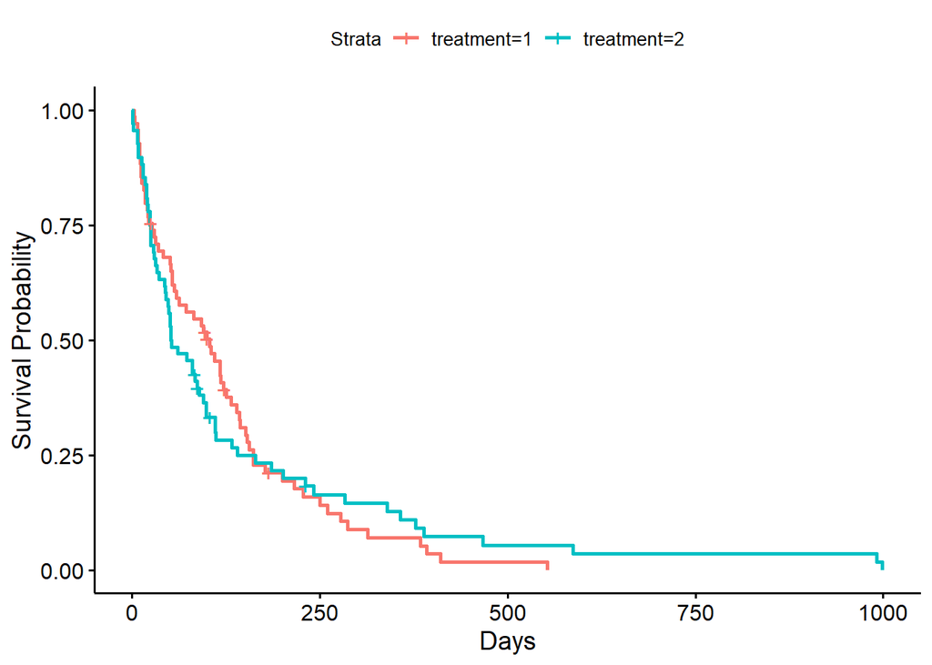

```r
ggsurvplot(fit=km, xlab="Days", ylab="Survival Probability")
```

Survival probability at 1 year (365 days) on standard vs test treatment

```r
summary(km, times=365)
```

```
## Call: survfit(formula = Surv(survival, status) ~ treatment, data = d)
##
##                 treatment=1
##         time       n.risk      n.event     survival      std.err lower 95% CI
##     365.0000       4.0000      60.0000       0.0708       0.0336       0.0279
## upper 95% CI
##       0.1795
##
##                 treatment=2
##         time       n.risk      n.event     survival      std.err lower 95% CI
##     365.0000       6.0000      58.0000       0.1098       0.0407       0.0530
## upper 95% CI
##       0.2272
```

```r
summary(km, times=183)
```

```
## Call: survfit(formula = Surv(survival, status) ~ treatment, data = d)
##
##                 treatment=1
##         time       n.risk      n.event     survival      std.err lower 95% CI
##     183.0000      12.0000      52.0000       0.2124       0.0514       0.1322
## upper 95% CI
##       0.3414
##
##                 treatment=2
##         time       n.risk      n.event     survival      std.err lower 95% CI
##     183.0000      14.0000      51.0000       0.2329       0.0529       0.1492
## upper 95% CI
##       0.3634
```

```r
print(km)
```

```
## Call: survfit(formula = Surv(survival, status) ~ treatment, data = d)
##
##              n events median 0.95LCL 0.95UCL
## treatment=1 69     64  103.0      59     132
## treatment=2 68     64   52.5      44      95
```

Answer: 103 days on standard treatment vs 52 days on test treatment Interpretation:

The test treatment outperforms the standard treatment on survival probability at 6 months and 1 year. However, the KM plot shows that this pattern is not consistent. For the first 24 days,both treatments have comparable survival probablities (around 75%). After that, the standard treatment outperforms the test treatment on survival probablity until around 200 days. Beyond 200 days, the test treatment shows better survival probablity. This could mean that it takes about 6 months to start seeing the effects of the new drug. Semi-parametric and parametric analysis Predictor variables selected for analysis: Treatment: We want to examine the effect of the two treatments on survival outcomes Months from diagnosis: People diagnosed late may not respond effectively to treatment Age (years): Older patients may respond differently to treatment than younger patients Prior chemotherapy (0=no, 1=yes): Prior chemo may influence the outcome of the treatment. Cell type: There are two main types of lung cancer: small cell (2=small cell) and non-small cell (1=squamous, 3=adeno, 4=large). The treatment may respond differently to the type of cancer. Variables not considered as predictors: Karnofsky score: This score measures the ability of cancer patients to perform ordinary tasks. It may be used to determine a patient’s prognosis, to measure changes in a patient’s ability to function, or to decide if a patient could be included in a clinical trial. It is unclear how it may related to treatment outcome. Feature engineering

```r
d$cancer_type <- ifelse(d$cell_type=="2", "small_cell", "non-small_cell")
d$cancer_type <- factor(d$cancer_type)
d$cancer_type <- relevel(d$cancer_type, ref="small_cell")
```

Cox proportional hazard model

```r
cox <- coxph(Surv(survival, status) ~ treatment + cancer_type + age + months_from_diagnosis +
            prev_chemo + treatment*age + treatment*cancer_type, data=d, method="breslow")
summary(cox)
```

```
## Call:
## coxph(formula = Surv(survival, status) ~ treatment + cancer_type +
##     age + months_from_diagnosis + prev_chemo + treatment * age +
##     treatment * cancer_type, data = d, method = "breslow")
##
##   n= 137, number of events= 128
##
##                                            coef  exp(coef)   se(coef)      z
## treatment2                            0.5548101  1.7416103  1.2960090  0.428
## cancer_typenon-small_cell            -0.3942409  0.6741916  0.2590624 -1.522
## age                                   0.0039121  1.0039198  0.0122544  0.319
## months_from_diagnosis                 0.0065941  1.0066159  0.0092066  0.716
## prev_chemo1                          -0.1527570  0.8583383  0.2335423 -0.654
## treatment2:age                       -0.0002618  0.9997383  0.0205105 -0.013
## treatment2:cancer_typenon-small_cell -0.5622573  0.5699211  0.4004749 -1.404
##                                      Pr(>|z|)
## treatment2                              0.669
## cancer_typenon-small_cell               0.128
## age                                     0.750
## months_from_diagnosis                   0.474
## prev_chemo1                             0.513
## treatment2:age                          0.990
## treatment2:cancer_typenon-small_cell    0.160
##
##                                      exp(coef) exp(-coef) lower .95 upper .95
## treatment2                              1.7416     0.5742    0.1373    22.086
## cancer_typenon-small_cell               0.6742     1.4833    0.4058     1.120
## age                                     1.0039     0.9961    0.9801     1.028
## months_from_diagnosis                   1.0066     0.9934    0.9886     1.025
## prev_chemo1                             0.8583     1.1650    0.5431     1.357
## treatment2:age                          0.9997     1.0003    0.9603     1.041
## treatment2:cancer_typenon-small_cell    0.5699     1.7546    0.2600     1.249
##
## Concordance= 0.58  (se = 0.03 )
## Likelihood ratio test= 13.24  on 7 df,   p=0.07
## Wald test            = 14.9  on 7 df,   p=0.04
## Score (logrank) test = 15.79  on 7 df,   p=0.03
```

Exponential, Weibull, and log-logistic parametric models

```r
exp <- survreg(Surv(survival, status) ~ treatment + cancer_type + age + months_from_diagnosis +
            prev_chemo + treatment*age + treatment*cancer_type, data=d, dist="exponential")

weibull <- survreg(Surv(survival, status) ~ treatment + cancer_type + age + months_from_diagnosis +
            prev_chemo + treatment*age + treatment*cancer_type, data=d, dist="weibull")

loglogistic <- survreg(Surv(survival, status) ~ treatment + cancer_type + age + months_from_diagnosis +
            prev_chemo + treatment*age + treatment*cancer_type, data=d, dist="loglogistic")

#install.packages('stargazer')
library(stargazer)
stargazer(cox, exp, weibull, loglogistic, type="text")
```

```
##
## ================================================================================================
##                                                          Dependent variable:
##                                      -----------------------------------------------------------
##                                                               survival
##                                             Cox        exponential Weibull  survreg: loglogistic
##                                        prop. hazards
##                                             (1)            (2)       (3)            (4)
## ------------------------------------------------------------------------------------------------
## treatment2                                 0.555         -0.506     -0.498         -1.640
##                                           (1.296)        (1.324)   (1.412)        (1.400)
##
## cancer_typenon-small_cell                 -0.394         0.425*     0.446         0.779**
##                                           (0.259)        (0.257)   (0.279)        (0.314)
##
## age                                        0.004         -0.007     -0.007         -0.005
##                                           (0.012)        (0.012)   (0.013)        (0.014)
##
## months_from_diagnosis                      0.007         -0.008     -0.008         -0.005
##                                           (0.009)        (0.009)   (0.010)        (0.012)
##
## prev_chemo1                               -0.153          0.214     0.201          -0.077
##                                           (0.234)        (0.233)   (0.251)        (0.278)
##
## treatment2:age                            -0.0003        -0.001     -0.001         0.021
##                                           (0.021)        (0.021)   (0.022)        (0.022)
##
## treatment2:cancer_typenon-small_cell      -0.562         0.667*     0.628          0.111
##                                           (0.400)        (0.392)   (0.425)        (0.484)
##
## Constant                                                4.977***   4.906***       4.232***
##                                                          (0.748)   (0.810)        (0.878)
##
## ------------------------------------------------------------------------------------------------
## Observations                                137            137       137            137
## R2                                         0.092
## Max. Possible R2                           0.999
## Log Likelihood                           -499.265       -741.070   -740.365       -743.469
## chi2 (df = 7)                                           20.303***  15.452**       13.595*
## Wald Test                            14.900** (df = 7)
## LR Test                              13.239* (df = 7)
## Score (Logrank) Test                 15.792** (df = 7)
## ================================================================================================
## Note:                                                                *p<0.1; **p<0.05; ***p<0.01
```

Interpretation:

Cox proportional hazard model reports estimated hazard rates, which are pretty consistent with survival probabilities reported by Exponential and Weibull models, all of which are a little different from the log-logistic model. Hence, we will use the Cox PH model for interpretation.